# Routing in R Using the Open Source Routing Machine (OSRM)

Chris Hansen

2016-11-27

# Overview

I often find myself needing to establish the travel time or distance between arrays of addresses. In the past I have used ArcMap’s Network Analyst tool, but have found the syntax to be clunky at best, and the performance to be very mediocre. And, besides, I am often working in R and sometimes it’s nice to be able to do everything in the one environment, rather than doing the routing in Python, say, and then using the results in R.

The [open source routing machine](http://project-osrm.org/) is a very fast routing engine which can be accessed via an [HTTP API](https://github.com/Project-OSRM/osrm-backend/blob/master/docs/http.md), which means it can be queried relatviely easy from most languages, including R. And while public servers are available for use, it is also relatively easy to set up locally resulting in excellent throughput due to the lack of latency.

# Prerequisites

The following R pacakges are required:

- `rjson` for reading web service results in JSON format
- `bitops` used to decode polylines (has convenient bitshift operators, etc.)
- `sp` for spatial projections, etc.
- `leaflet` for rendering [leaflet](http://leafletjs.com/) maps in a browser

# Geocoding addresses

- [data science toolkit](http://www.datasciencetoolkit.org/) - doesn’t work at all for New Zealand
- Nominatim - finds addresses but probably only okay if approximate locations are acceptable.

The following code results in two addresses being geocoded which we will use as an origin and a destination later when using a routing service.

```r
library(rjson)

# use HERE API to geocode a start point...
get_location <- function(search_text,
                         app_id = params$app_id, app_code = params$app_code) {
   service <- "https://geocoder.api.here.com/6.2/geocode.json"
   query <- sprintf(
     "%s?app_id=%s&app_code=%s&searchtext=%s",
     service, app_id, app_code,
     gsub(" ", "%20", search_text, fixed = TRUE)
   )

   res1 <- jsonlite::fromJSON(query, simplifyVector = FALSE)
   res2 <- res1$Response$View[[1]]$Result[[1]]$Location

   list(
      lng = res2$DisplayPosition$Longitude,
      lat = res2$DisplayPosition$Latitude,
      address = res2$Address$Label
   )
}

# start point...
(o <- get_location("25 Edelweiss Grove, Timberlea, Upper Hutt"))
```

```
$lng
[1] 175.1085

$lat
[1] -41.10678

$address
[1] "25 Edelweiss Grv, Timberlea, Wellington 5018, New Zealand"
```

```r
# ...and destination
(d <- get_location("1 Pipitea Street, Wellington"))
```

```
$lng
[1] 174.7811

$lat
[1] -41.27568

$address
[1] "1 Pipitea St, Thorndon, Wellington 6011, New Zealand"
```

# Open Source Routing Machine (OSRM)

[Open Source Routing Machine](http://project-osrm.org/) is an open source route solver. It is written in C++ and runs on Linux (maybe other platforms, but stick with Linux), and is very fast. There is a nice web demo which uses the service as a back-end [here](http://map.project-osrm.org/). The back-end service is available to the public at https://router.project-osrm.org. Details, including usage policy, is available here.

The code below shows how to find a route between the origin and destination locations found above:

```r
(url <- paste0("http://cmhh.hopto.org/osrm/route/v1/driving/",
   o$lng,",",o$lat,";",d$lng,",",d$lat,"?overview=full"))
```

```
[1] "http://cmhh.hopto.org/osrm/route/v1/driving/175.10847,-41.10678;174.78112,-41.27568?overview=full"
```

```r
system.time({
  route <- jsonlite::fromJSON(url, simplifyVector = FALSE)
})
```

```
   user  system elapsed
  0.036   0.004   0.188
```

Again, assuming a route was successfully found, `route` will now contain a list including, among other things, time in seconds to traverse the route, distance in metres, and the route geomertry stored in [encoded polyline algorithm format](https://developers.google.com/maps/documentation/utilities/polylinealgorithm).

```r
route$routes[[1]]$duration
```

```
[1] 1752
```

```r
route$routes[[1]]$distance
```

```
[1] 35343.4
```

```r
route$routes[[1]]$geometry
```

```
[1] "~t{yFozwk`@[hAo@rAOKMEOAO?MByBnBD^Tj@DNDVNNr@|APh@Lp@p@~DBVV\\V\\XVzB~A^RNDV@\\AfAOVCXBPFJFTPh@v@XLTBj@ALBLHLNNT|BzDfAhBFL@LALAJGLiBhCyAnBcChDMRIPSp@Mh@G\\E\\ET`BLhAFnBRn@D^Fd@Lf@PTJXPZRLJTVVZJJNVHPLTTb@P`@LNT`@Tl@HPFNHRXz@XbAZ`B`@xAXbATlANjAHd@FbAHrABZJbBHzAL|AJxAHjAJjA@PTfC\\bDXhC\\dDZlC\\`Dp…
```

We write a function to convert the encoded route to a `SpatialLines` object:

```r
decode <- function(str, multiplier=1e5){

   if (!require(bitops)) stop("Package: bitops required.")
   if (!require(sp)) stop("Package: sp required.")

   truck <- 0
   trucks <- c()
   carriage_q <- 0

   for (i in 0:(nchar(str)-1)){
      ch <- substr(str, (i+1), (i+1))
      x <- as.numeric(charToRaw(ch)) - 63
      x5 <- bitShiftR(bitShiftL(x, 32-5), 32-5)
      truck <- bitOr(truck, bitShiftL(x5, carriage_q))
      carriage_q <- carriage_q + 5
      islast <- bitAnd(x, 32) == 0
      if (islast){
         negative <- bitAnd(truck, 1) == 1
         if (negative) truck <- -bitShiftR(-bitFlip(truck), 1)/multiplier
         else truck <- bitShiftR(truck, 1)/multiplier
         trucks <- c(trucks, truck)
         carriage_q <- 0
         truck <- 0
      }
   }
   lat <- trucks[c(T,F)][-1]
   lng <- trucks[c(F,T)][-1]
   res <- data.frame(lat=c(trucks[1],cumsum(lat)+trucks[1]),
                     lng=c(trucks[2],cumsum(lng)+trucks[2]))

   coordinates(res) <- ~lng+lat
   proj4string(res) <- CRS("+init=epsg:4326")
   return(SpatialLines(list(Lines(Line(res), 1)), CRS("+init=epsg:4326")))
}
```

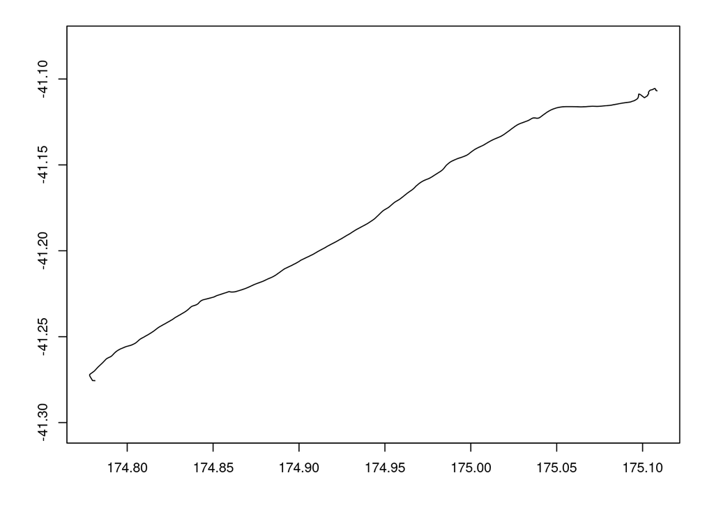

```r
par(mar=par()$mar-c(1,0,2.5,0), cex=0.8)
path <- decode(route$routes[[1]]$geometry, multiplier=1e5)
plot(path); axis(1); axis(2); box()
```

# Using `leaflet` to make a nicer map

It is relatively easy to make a nice interactive map. Here we draw a simple [leaflet](http://leafletjs.com/) map, and overlay the origin and destination points, as well as the route between.

```r
#make a string to nicely label the route
s <- route$routes[[1]]$duration
kms <- round(route$routes[[1]]$distance/1000, 1)
routelabel <- paste0(s%/%60, "m ", s%%60, "s , ", kms, "kms")

#create a basic map
library(leaflet)
m <- leaflet(width="100%") %>%
  addTiles()  %>%
  addPolylines(data=path, popup=routelabel, color = "#000000", opacity=1, weight = 3) %>%
  addMarkers(lng=o$lng, lat=o$lat, popup=o$address) %>%
  addMarkers(lng=d$lng, lat=d$lat, popup=d$address)
```

```r
m
```

[interactive chart not shown]

It’s also relatively straight forward to use different base maps, and a nice demo of some other providers can be found [here](http://leaflet-extras.github.io/leaflet-providers/preview/). For example:

```r
require(leaflet)
leaflet(width="100%", height=600) %>%
  addTiles(urlTemplate='http://{s}.tile.stamen.com/watercolor/{z}/{x}/{y}.png') %>%
  addTiles(urlTemplate='http://{s}.tile.openstreetmap.se/hydda/roads_and_labels/{z}/{x}/{y}.png') %>%
  addPolylines(data=path, popup=routelabel, color = "#000000", opacity=1, weight = 3) %>%
  addMarkers(lng = o$lng, lat = o$lat, popup = o$address) %>%
  addMarkers(lng = d$lng, lat = d$lat, popup = d$address)
```

[interactive chart not shown]